# nytimes_clicks

mcdevitt

31 mars 2017

## NYTimes Click Thru Evaluation

- From the data sets at http://stat.columbia.edu/~rachel/datasets/ there are 31 data sets named nyt1.csv, nyt2.csv, …
- Each set represents one simulated day’s worth of ads shown and click recorded on New York Times home page in May 2012
- Each row represents one user
- Five columns represent :
  - age,
  - gender (0 = female, 1 = male),
  - number of impressions,
  - number of clicks, and
  - whether user logged in.

#### Read in base data file

```r
home_dir <- "~/_smu/_src/nytimes_clicks"
data_dir <- paste0(home_dir, "/data")
setwd(home_dir)


# ...   toggle file_exists TRUE/FALSE depending on if .Rda file already locally saved

file_exists <- TRUE

if (file_exists)
{
    load("./data/nytc.Rda") # ...   load the saved data frame ...
} else {
    fileLocation <- "http://stat.columbia.edu/~rachel/datasets/nyt1.csv"
    df_nytc <- read.csv(url(fileLocation))
    save(df_nytc, file = "./data/nytc.Rda")
}
```

#### **distribution of the Age column**

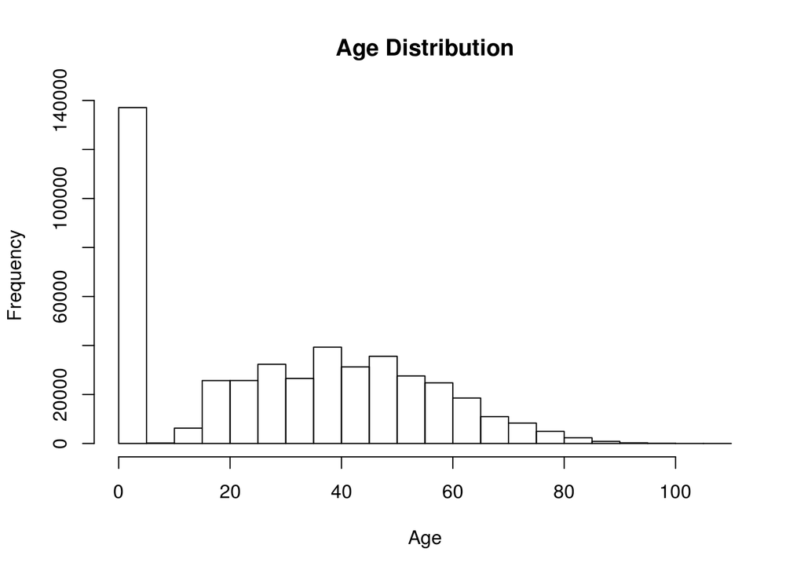

```r
hist(df_nytc$Age, main="Age Distribution", xlab = "Age")
```

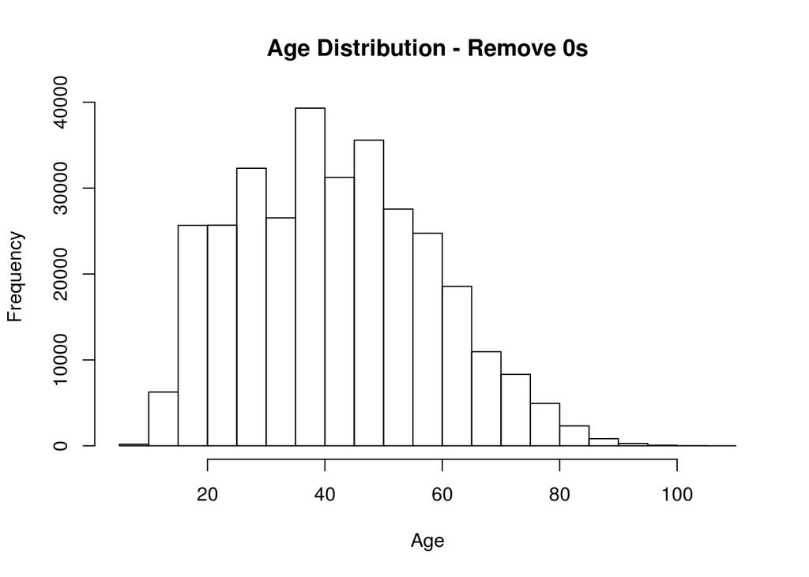

```r
hist(df_nytc[df_nytc$Age > 0,]$Age, main="Age Distribution - Remove 0s", xlab = "Age")
```

#### **distribution and range of the Clicks column**

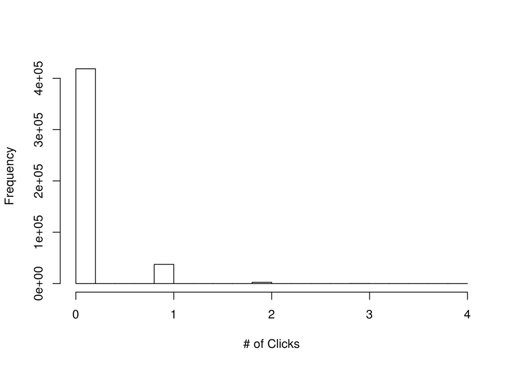

```r
hist(df_nytc$Clicks, main="", xlab="# of Clicks")
```

```r
range(df_nytc$Clicks)
```

```
## [1] 0 4
```

#### **Create a new variable ageGroup that categorizes age into following groups:**

#### * < 18, 18–24, 25–34, 35–44, 45–54, 55–64 and 65+.

##### * Name the levels of ‘Age_Group’ for readability

```r
df_nytc$Age_Group <- cut(df_nytc$Age, c(-Inf, 18, 24, 34, 44, 54, 64, Inf))

levels(df_nytc$Age_Group) <- c("<18", "18-24", "25-34", "35-44", "45-54", "55-64", "65+")
```

#### **Use sub set of data called “imp_sub” where Impressions > 0 in your data set.**

#### * Create a new variable called click-through-rate (clk_thru_rate = clicks / impression).

#### * Use this imp_sub data set to do further analysis.

```r
df_imp_sub <- df_nytc[(df_nytc$Impressions > 0),]
df_imp_sub$clk_thru_rate <- df_imp_sub$Clicks / df_imp_sub$Impressions
```

#### **Plot distributions of number impressions for the age groups**

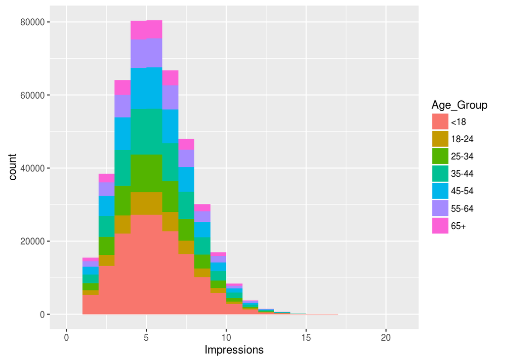

```r
ggplot(subset(df_imp_sub, Impressions > 0), aes(x = Impressions, fill = Age_Group)) +
    geom_histogram(binwidth = 1)
```

***  
#### **Plot distributions of click-through-rate (clk_thru_rate = click/impression) for the age groups**

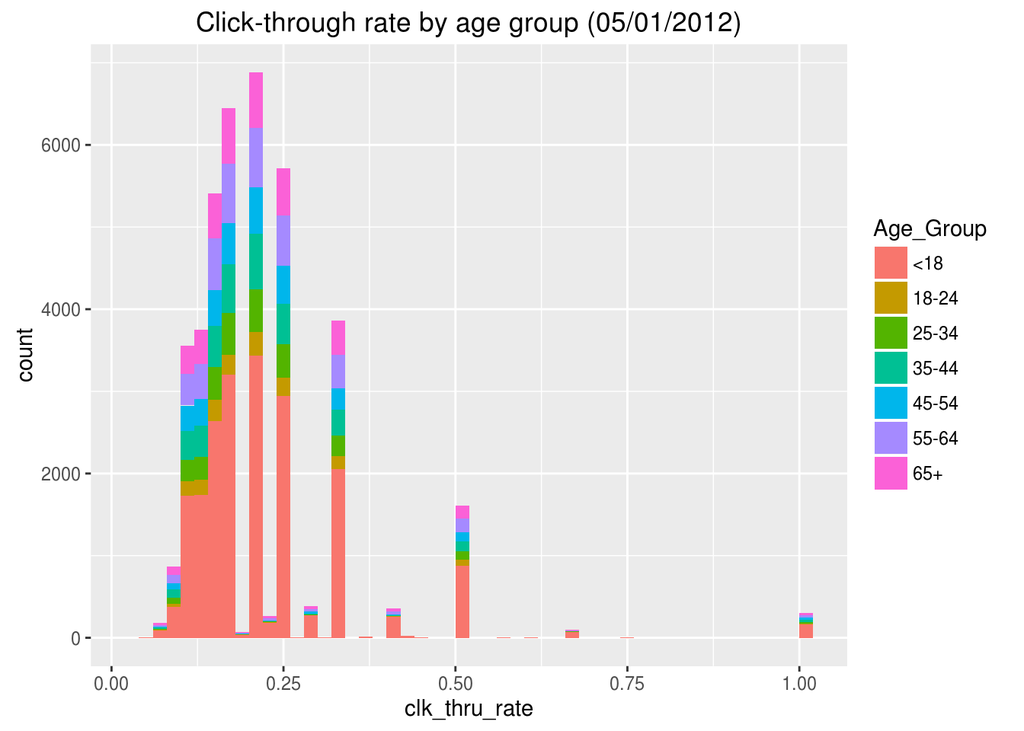

```r
ggplot(subset(df_imp_sub, clk_thru_rate > 0), aes(x = clk_thru_rate, fill = Age_Group))+
    labs(title="Click-through rate by age group (05/01/2012)")+
    geom_histogram(binwidth = .02)
```

#### **Define a new variable to segment users based on click-through-rate behavior.**

#### * clk_thru_rate< 0.2, 0.2<=clk_thru_rate <0.4, 0.4<= clk_thru_rate<0.6, 0.6<=clk_thru_rate<0.8, clk_thru_rate>0.8

```r
df_imp_sub$clk_thru_rate_counts <- cut(df_imp_sub$clk_thru_rate, c(-Inf, 0.2, 0.4, 0.6, 0.8, Inf))
```

#### **Get the total number of Male, Impressions, Clicks and Signed_In**

#### * (0 = Female, 1 = Male)

```r
n_males <- dim(df_imp_sub[df_imp_sub$Gender == 1,])[1]
n_imps <- dim(df_imp_sub[df_imp_sub$Impressions == 1,])[1]
n_clicks <- dim(df_imp_sub[df_imp_sub$Clicks == 1,])[1]
n_signed_in <- dim(df_imp_sub[df_imp_sub$Signed_In == 1,])[1]
```

```
## Number of males       =  167146
```

```
## Number of impressions =  15483
```

```
## Number of clicks      =  37372
```

```
## Number of signed in   =  319198
```

#### **Get the mean of Age, Impressions, Clicks, clk_thru_rate and percentage of males and signed_In**

```r
col_drops <- c("Age_Group", "clk_thru_rate_counts")
df_imp_sub_tmp <- df_imp_sub[ , !(names(df_imp_sub) %in% col_drops)]

means_all <- sapply(df_imp_sub_tmp, mean)

means_all
```

```
##           Age        Gender   Impressions        Clicks     Signed_In
##   29.48400988    0.36705133    5.04102992    0.09321768    0.70095635
## clk_thru_rate
##    0.01847053
```

#### Get the means of Impressions, Clicks, clk_thru_rate and percentage of males and signed_In **by AgeGroup.**

```r
df_imp_sub <- df_imp_sub[c(1:5,7,6,8)]

aggregate(df_imp_sub[, 1:6], list(df_imp_sub$Age_Group), mean)
```

```
##   Group.1       Age    Gender Impressions     Clicks Signed_In
## 1     <18  1.974572 0.0790648    5.033534 0.14167788 0.1231528
## 2   18-24 21.268493 0.5339864    5.043240 0.04880905 1.0000000
## 3   25-34 29.503573 0.5319977    5.026055 0.05081227 1.0000000
## 4   35-44 39.493195 0.5317072    5.054749 0.05202148 1.0000000
## 5   45-54 49.492928 0.5292192    5.045172 0.05062260 1.0000000
## 6   55-64 59.497459 0.5359633    5.053484 0.10246952 1.0000000
## 7     65+ 72.988409 0.3632512    5.046925 0.15233226 1.0000000
##   clk_thru_rate
## 1   0.028141310
## 2   0.009720481
## 3   0.010146329
## 4   0.010286330
## 5   0.009957612
## 6   0.020306816
## 7   0.029802702
```

#### **Create a table of clk_thru_rate Group vs Age Group counts.**

```r
x_table <- ddply(df_imp_sub, .(df_imp_sub$clk_thru_rate_counts, df_imp_sub$Age_Group), nrow)
names(x_table) <- c("Clk Thru Rate Group", "Age Group", "Freq")

x_table
```

```
##    Clk Thru Rate Group Age Group   Freq
## 1           (-Inf,0.2]       <18 148412
## 2           (-Inf,0.2]     18-24  34540
## 3           (-Inf,0.2]     25-34  56980
## 4           (-Inf,0.2]     35-44  69424
## 5           (-Inf,0.2]     45-54  62936
## 6           (-Inf,0.2]     55-64  43147
## 7           (-Inf,0.2]       65+  27261
## 8            (0.2,0.4]       <18   5735
## 9            (0.2,0.4]     18-24    391
## 10           (0.2,0.4]     25-34    689
## 11           (0.2,0.4]     35-44    820
## 12           (0.2,0.4]     45-54    776
## 13           (0.2,0.4]     55-64   1104
## 14           (0.2,0.4]       65+   1108
```

[output cut: 20 more lines]

#### **One more plot you think which is important to look at.**

- this is based on plot explanation from : http://stackoverflow.com/questions/23619375/how-to-plot-a-matrix-of-variable-interactions

[figure not shown]

```r
df_exp_plot <- df_imp_sub[c(6, 7, 2)]

chart.Correlation(iris[-5], bg=iris$Species, pch=21)
```

… end_of_file  
***